# DV Assignment 2: The Hidden Gap Between Test Performance and School Advice

Author

Group 1: Matheus Nacif, Ilinca Anton, Isabella Braune

Published

October 11, 2026

**Github link: https://github.com/bellabraune/dv-2026-group1.git**

## Research question

**Do schools with similar test results give similar secondary-school advice? (inference)**

At the end of primary school, pupils receive advice on which secondary-school track to follow. This advice combines teacher judgment with results from the *doorstroomtoets*. We examine whether schools with similar test performance give similar advice, and whether this relationship differs with the socioeconomic composition of their pupils (*schoolweging*).

Our main audience is policymakers and the general public. We therefore aim to show differences in the percentage of pupils receiving HAVO-or-higher advice, rather than focusing on regression coefficients.

## Data Processing

After understanding the data and producing our AI_CONTEXT.md file with all the specifications of the datasets we start processing the data in order to work with it.

DUO suppresses counts below five for privacy (DUO, 2025a, 2025b). Rather than dropping these observations, which would remove information from many schools, we replace them with 2.5, the midpoint of the possible values (1–4).

To calculate HAVO+ advice, we combine the HAVO, HAVO/VWO, and VWO categories. HAVO/VWO counts fully because both tracks meet the HAVO threshold, whereas VMBO-GT/HAVO is excluded because it includes a lower track. We divide this total by the number of pupils receiving advice, excluding those for whom no advice was recorded (`ADVIES_NIET_MOGELIJK`).

### Exploring test results and school advice

To measure test performance, we used the percentage of students reaching the target reference levels in maths (1S) and reading (2F), which are comparable across test providers (DUO, 2025a). Before combining them into one measure, we checked whether they showed similar relationships with HAVO+ advice, as averaging could otherwise hide important differences (Figure 1).

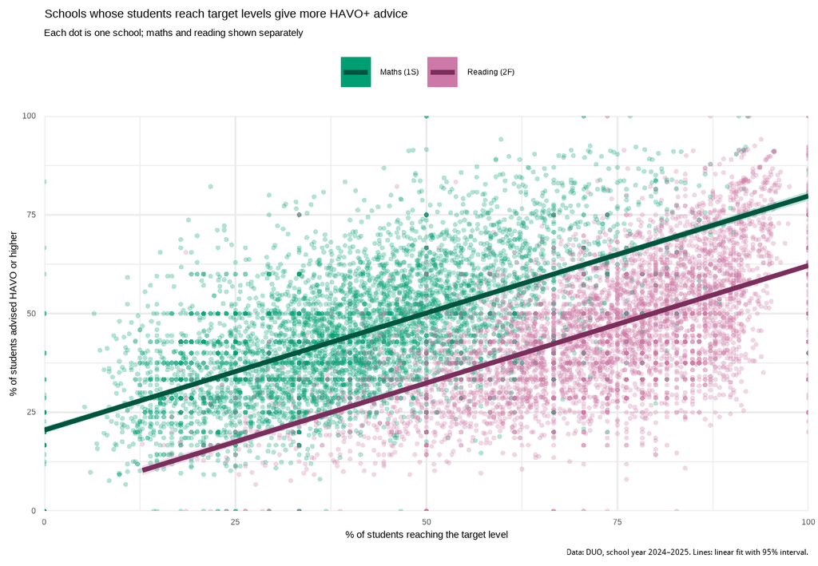

```
# A tibble: 2 × 3
  subject     r slope
  <chr>   <dbl> <dbl>
1 maths   0.615 0.593
2 reading 0.605 0.595
```

Figure 1 shows similar relationships for maths and reading (both r = 0.61), suggesting that neither subject has a substantially stronger association with HAVO+ advice. We therefore averaged the two percentages into one test-performance measure for the remaining analysis.

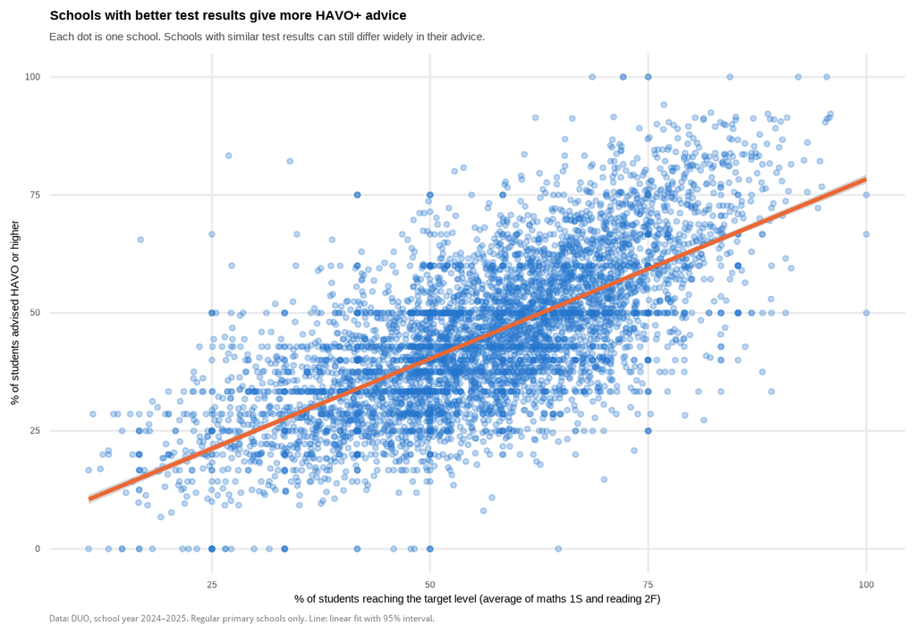

```
Call:
lm(formula = pct_havo_plus ~ pct_test, data = exploratory_data)

Residuals:
    Min      1Q  Median      3Q     Max
-51.501  -7.762  -0.352   7.627  60.611

Coefficients:
            Estimate Std. Error t value Pr(>|t|)
(Intercept)  2.21862    0.59961    3.70 0.000217 ***
pct_test     0.76156    0.01036   73.53  < 2e-16 ***
---
Signif. codes:  0 '***' 0.001 '**' 0.01 '*' 0.05 '.' 0.1 ' ' 1

Residual standard error: 11.63 on 5919 degrees of freedom
Multiple R-squared:  0.4774,    Adjusted R-squared:  0.4773
F-statistic:  5406 on 1 and 5919 DF,  p-value: < 2.2e-16
```

Figure 2 shows a strong positive relationship between test performance and HAVO+ advice across 5,921 schools (r = 0.69). A 10-percentage-point increase in test performance was associated with approximately 7.6 percentage points more HAVO+ advice (b = 0.76).

However, test performance explained only 48% of the variation in advice (R² = 0.48), with substantial variation remaining around the fitted line (residual SE = 11.6 percentage points). This led us to investigate whether school disadvantage could help explain these differences.

### Exploring school weighting

We chose to investigate schoolweging, a measure of the socioeconomic disadvantage of a school’s student population, where higher values indicate greater disadvantage. Rather than examining whether disadvantage is simply associated with higher or lower advice, we wanted to see whether it changes the relationship between test performance and HAVO+ advice.

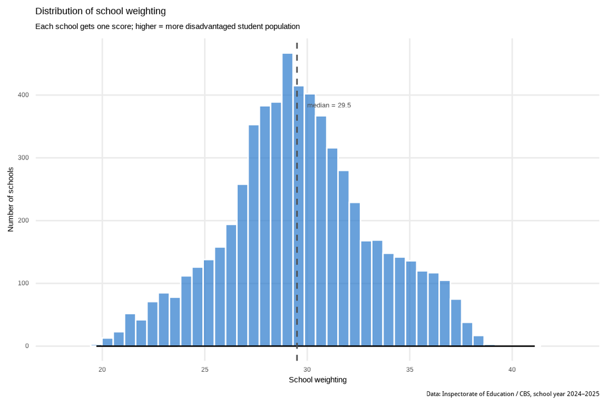

Figure 3 shows that school weighting is continuously distributed around a median of approximately 29.5, without a clear cutoff between more and less disadvantaged schools. We therefore kept it continuous in our moderation model rather than dividing schools into categories.

## Moderation analysis

### Prepare the analysis data

For the moderation analysis, we combined the advice and test-performance data with school weighting. However, the school-weighting file uses different location identifiers, so we could only match schools by their main school code. For schools with multiple locations, we assigned the weighting of the first listed location to all of them.

```
# A tibble: 1 × 2
  median_spread max_spread
          <dbl>      <dbl>
1          2.22       14.7
```

```
Number of rows in the moderation dataframe: 5876
```

```
School locations in the model affected by the first-location choice: 305 of 5876
```

```
# A tibble: 6 × 5
  inst  vest  pct_havo_plus pct_test schoolweging
  <chr> <chr>         <dbl>    <dbl>        <dbl>
1 00AP  00             33.3     48.5         34.8
2 00AR  00             28.6     46.5         27.4
3 00AV  00             33.3     47.8         30.5
4 00AZ  00             42.9     48.2         32.4
5 00BB  00             16.7     29.2         32.3
6 00BS  00             28.6     63.1         29.1
```

### Model school disadvantage as a moderator

We fitted a linear regression with an interaction between test performance and school weighting. As discussed earlier, this allows us to examine whether the relationship between test results and advice changes depending on how disadvantaged a school’s student population is.

```
# A tibble: 1 × 2
  r_squared interaction
      <dbl>       <dbl>
1     0.585     -0.0354
```

#### Representative predictions

To make this interaction easier to interpret, we calculated predictions at the 25th and 75th percentiles of school weighting (27.4 and 31.8). These represent relatively lower and higher disadvantage without relying on extreme values. School weighting remains continuous in the model.

```
Call:
lm(formula = pct_havo_plus ~ pct_test, data = model_data)

Coefficients:
(Intercept)     pct_test
     2.1361       0.7629
```

```
# A tibble: 200 × 2
   pct_test   fit
      <dbl> <dbl>
 1     10    9.77
 2     10.4 10.1
 3     10.8 10.4
 4     11.2 10.7
 5     11.6 11.0
 6     12.0 11.3
 7     12.4 11.6
 8     12.8 11.9
 9     13.2 12.2
10     13.6 12.5
# ℹ 190 more rows
```

At 70% test attainment, the model predicts approximately 56% HAVO+ advice at lower disadvantage, compared with 47% at higher disadvantage. This 9-percentage-point gap illustrates our main finding: schools with similar test results can give different proportions of HAVO+ advice, with the predicted gap widening at higher performance levels.

### Interactive visualization

We designed the interactive visualization to make the moderation results understandable without relying on regression coefficients. It initially shows the overall relationship between test performance and HAVO+ advice. Readers can then switch to predictions for lower and higher school disadvantage to see how the relationship changes.

We chose two representative lines to make the difference clear without overcrowding the graph. Individual schools remain visible to show the variation around the predictions, while highlighting the lowest and highest quarters of school weighting helps readers connect the model to the observed data.

Finally, hover labels show predicted HAVO+ advice and its difference from the higher-disadvantage reference in percentage points, making the comparison easier to interpret.

[interactive chart not shown]

### Conclusion

Our results suggest that school disadvantage is associated with how closely secondary-school advice follows test performance. Although schools with better test results generally give more HAVO+ advice, this relationship is weaker in more disadvantaged schools. The difference is particularly noticeable at higher levels of test performance.

However, these are school-level comparisons. We cannot conclude that individual pupils with identical test results receive different advice because of their socioeconomic background. Other differences between schools may also contribute to the pattern, especially considering the differences in test providers and how these are interpreted, which is an important debate now.

Nevertheless, the analysis shows that test performance alone does not fully explain differences in secondary-school advice, and that school disadvantage is relevant to understanding them.